# Data science applications - NAFLD

Agosteo, Palmiotto, Fabbri, Petrella

2023-05-22

# Libraries used for this project

```r
library(corrplot)
library(ggplot2)
library(gridExtra)
library(survival)
library(survminer)
library(mfp)
library(flexsurv)
library(DescTools)
```

Here below we upload the dataset from the package. We notice that there are a lot of missing observations, therefore we remove them from the dataframe.

```r
data(nafld, package="survival")
nafld <- nafld1
print(dim(nafld))
```

```
## [1] 17549     9
```

```r
nafld <- na.omit(nafld)
print(dim(nafld))
```

```
## [1] 12562     9
```

```r
head(nafld)
```

|  | id | age | male | weight | height | bmi | case.id | futime | status |
| --- | --- | --- | --- | --- | --- | --- | --- | --- | --- |
| 3631 | 1 | 57 | 0 | 60.0 | 163 | 22.69094 | 10630 | 6261 | 0 |
| 8458 | 2 | 67 | 0 | 70.4 | 168 | 24.88403 | 14817 | 624 | 0 |
| 6298 | 3 | 53 | 1 | 105.8 | 186 | 30.45354 | 3 | 1783 | 0 |
| 15398 | 4 | 56 | 1 | 109.3 | 170 | 37.83010 | 6628 | 3143 | 0 |
| 14423 | 6 | 39 | 0 | 63.9 | 155 | 26.61559 | 7144 | 1581 | 0 |
| 9518 | 7 | 49 | 0 | 66.2 | 161 | 25.51934 | 7507 | 3109 | 0 |

```r
# corr df will be used for the visual analysis on correlation
corr_df = nafld[c(-1, -7)]
corr_df$status = factor(corr_df$status)
corr_df$male = factor(corr_df$male)
```

# Empirical distributions

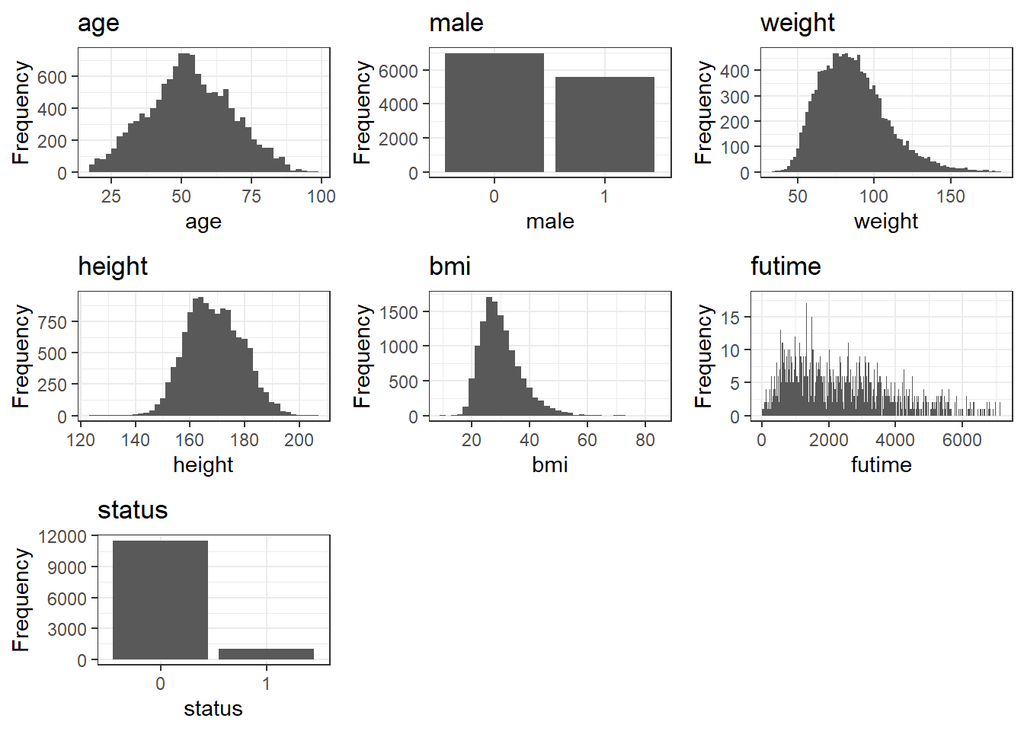

```r
# Create a vector of variable names to be plotted
var_names <- names(corr_df)

# Create a list to store the plots
plots <- list()

# Loop through each variable
for (var in var_names) {
  # Check if the variable is numeric or factor
  if (is.numeric(corr_df[[var]])) {
    # Create a histogram for numeric variables
    p <- ggplot(corr_df, aes_string(x = var)) +
         geom_histogram(binwidth = 2) +
         labs(title = var, x = var, y = "Frequency") +
         theme_bw()
    # Add the plot to the list
    plots[[length(plots) + 1]] <- p
  } else if (is.factor(corr_df[[var]])) {
    # Create a bar chart for factor variables
    p <- ggplot(corr_df, aes_string(x = var)) +
         geom_bar() +
         labs(title = var, x = var, y = "Frequency") +
         theme_bw()
    # Add the plot to the list
    plots[[length(plots) + 1]] <- p
  }
}

# Combine the plots into a single figure
grid.arrange(grobs = plots, ncol = 3)
```

```r
summary(corr_df[c(-6,-7)])
```

```
##       age        male         weight           height           bmi
##  Min.   :18.00   0:6993   Min.   : 33.40   Min.   :123.0   Min.   : 9.207
##  1st Qu.:44.00   1:5569   1st Qu.: 70.00   1st Qu.:162.0   1st Qu.:25.127
##  Median :53.00            Median : 84.00   Median :169.0   Median :28.870
##  Mean   :53.55            Mean   : 86.41   Mean   :169.3   Mean   :30.069
##  3rd Qu.:64.00            3rd Qu.: 99.30   3rd Qu.:177.0   3rd Qu.:33.703
##  Max.   :98.00            Max.   :181.70   Max.   :207.0   Max.   :84.396
```

The plots above represent the empirical distribution of our data. We notice that age seems to be centered at around 55 with a steadily increasing concentration towards the mean, while height seems to approximate a normal distribution. Weight and BMI, on the other hand, appear to be positively skewed, showing a heavier tail on the right side, while male (1 if male, 0 if female) looks slightly unbalanced, showing a higher number of female individuals in the study. “futime” represents the time to death and its density slowly decreases with a strong tail on the right.

## Checking the correlation structure

Here we plotted the dataset’s correlation matrix. We noticed a high correlation between weight and BMI. This is expected, since weight, along with height, are used to compute BMI. To avoid any issues such as collinearity, we choose to not include weight in any of the models. We exclude height as well, since it’s related to BMI even though they’re not linearly correlated.

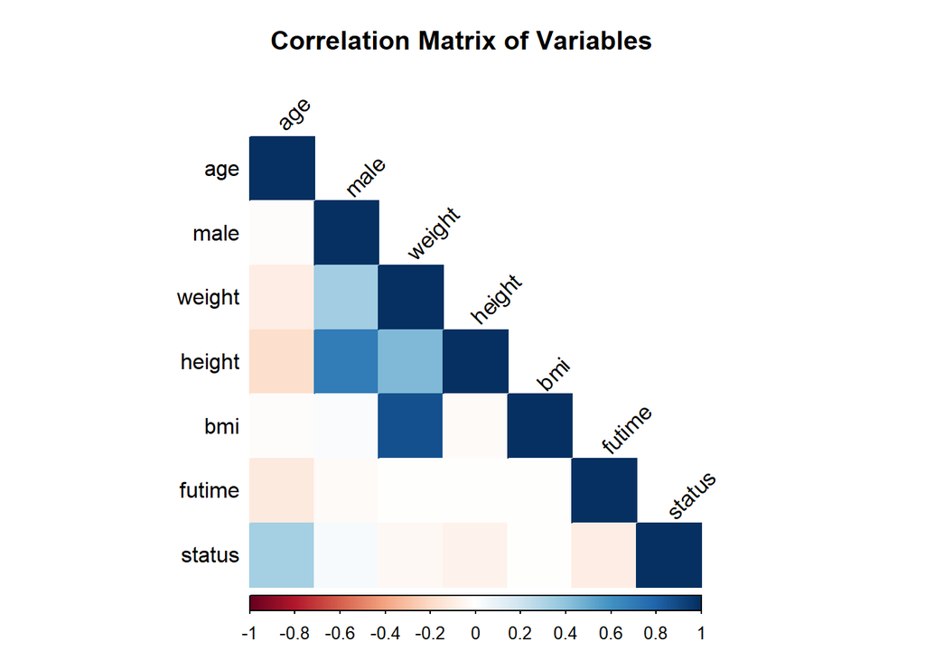

```r
# Calculate the correlation matrix
corr_df[] <- lapply(corr_df, as.numeric)
cor_matrix <- cor(corr_df)

# Generate a correlation plot with adjusted margin
corrplot(cor_matrix, method = "color", type = "lower",
         title = "Correlation Matrix of Variables",
         tl.col = "black", tl.srt = 45, mar=c(0, 0, 3, 0))
```

We also divide the quantitative variables into classes. The cutoff points have been selected manually: we refrained from using quantiles since we wanted to avoid weird cutoffs. In other cases, such as BMI, we choose to split it according to the WHO indications: - Underweight: BMI below 18.5 - Normal weight: BMI between 18.5 and 24.9 - Overweight: BMI between 25 and 29.9 - Class 1 obesity: BMI between 30 and 34.9 - Class 2 obesity: BMI between 35 and 39.9 - Class 3 obesity: BMI of 40 or higher

```r
nafld$agecl <- cut(nafld$age, breaks = c(0, 30, 45, 60, 75, Inf),
             labels = c("0<=-30", "30<=-45", "45<=-60", "60<=-75",">=75"),
             right=F, include.lowest=T)

bmi_breaks <- c(0,18.5, 25, 30, 35, 40, Inf)
nafld$bmicl <- cut(nafld$bmi, breaks = bmi_breaks,
             labels = c("Underweight", "Normal weight", "Overweight",
                        "Class 1 obesity","Class 2 obesity", "Class 3 obesity"))
```

## KAPLAN-MEIER

Next we estimate the survival functions using the Kaplan-Meier estimator.

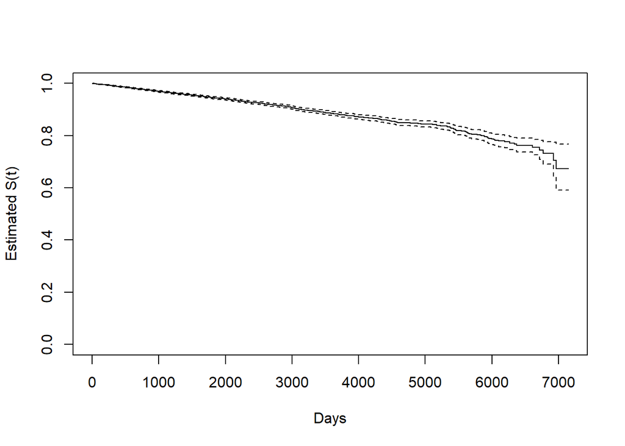

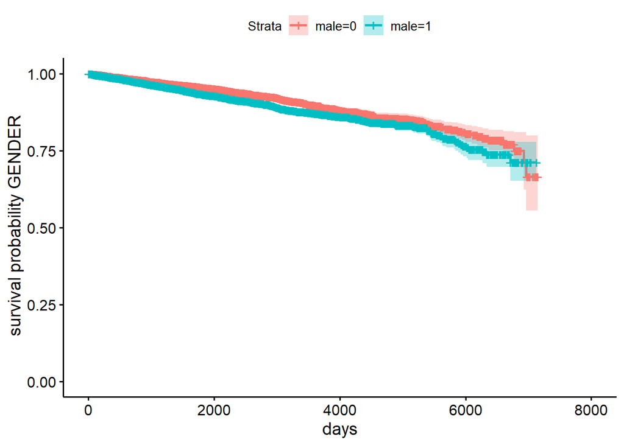

```r
attach(nafld)

# Create the survival data object
surv_obj <- Surv(futime,status)

# General survival function S(t) with Kaplan-Meier

result_KM <- survfit(surv_obj~1)
plot(result_KM, xlab="Days", ylab="Estimated S(t)")


# Survival functions for gender
surv_male = Surv(futime, status)
km_male = survfit(surv_male ~ male)
ggsurvplot(km_male,  conf.int = TRUE, xlab = "days", ylab = " survival probability GENDER",data=nafld)
```

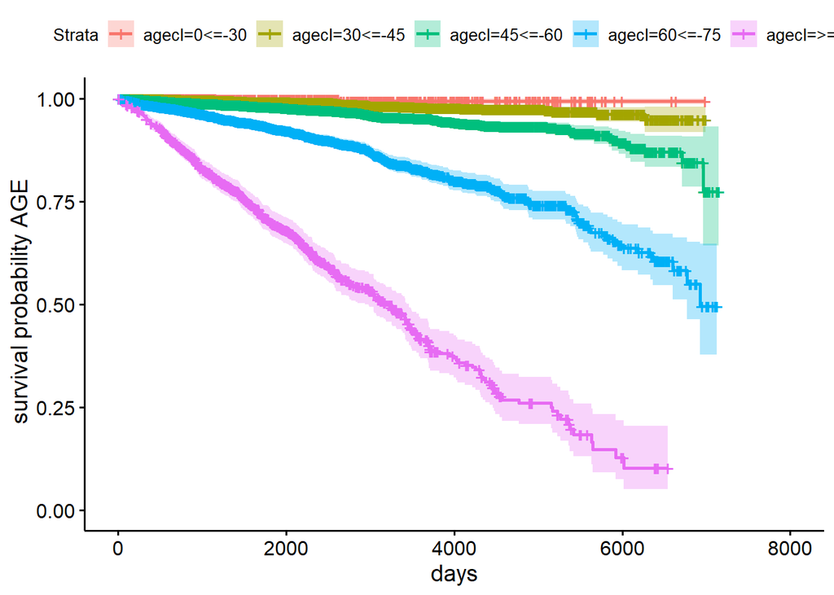

```r
# Survival function for age
surv_agecl <- survfit((surv_obj) ~ agecl)
ggsurvplot(surv_agecl,  conf.int = TRUE, xlab = "days", ylab = " survival probability AGE",data=nafld)
```

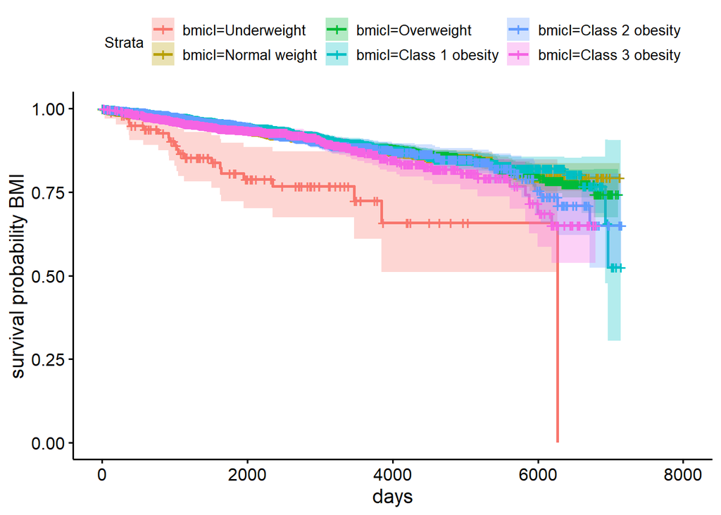

```r
# Survival function for bmi
surv_bmicl <- survfit((surv_obj) ~ bmicl)
ggsurvplot(surv_bmicl,  conf.int = TRUE, xlab = "days", ylab = "survival probability BMI",data=nafld)
```

```r
detach(nafld)
```

The survival curves seem to be well differentiated for age and the underweight class for bmi, nevertheless we check this condition using the log-rank test and the Wilcoxon test. Both tests have different strengths. The log-rank tends to be more powerful when the hazards are proportional. It also gives equal weight to all events, regardless of when they occur. This makes it sensitive to differences in survival probabilities later in time. Wilcoxon, on the other hand, performs better when the hazards are not proportional; moreover, Wilcoxon assigns a greater weight to earlier observations. As we can see from the results below, both tests show that the survival curves are significantly different.

```r
attach(nafld)
# Breslow tests (Wilcoxon test)
survdiff(surv_obj ~ agecl, rho=1)
```

```
## Call:
## survdiff(formula = surv_obj ~ agecl, rho = 1)
##
##                  N Observed Expected (O-E)^2/E (O-E)^2/V
## agecl=0<=-30   692     1.88     47.5      43.8      48.6
## agecl=30<=-45 2705    37.12    226.5     158.3     222.8
## agecl=45<=-60 4902   166.19    390.8     129.1     232.3
## agecl=60<=-75 3191   340.67    226.5      57.6      80.0
## agecl=>=75    1072   406.48     61.1    1953.0    2194.3
##
##  Chisq= 2472  on 4 degrees of freedom, p= <2e-16
```

```r
survdiff(surv_obj ~ male, rho=1)
```

```
## Call:
## survdiff(formula = surv_obj ~ male, rho = 1)
##
##           N Observed Expected (O-E)^2/E (O-E)^2/V
## male=0 6993      475      539      7.57      18.5
## male=1 5569      478      414      9.85      18.5
##
##  Chisq= 18.5  on 1 degrees of freedom, p= 2e-05
```

```r
survdiff(surv_obj ~ bmicl, rho=1)
```

```
## Call:
## survdiff(formula = surv_obj ~ bmicl, rho = 1)
##
##                          N Observed Expected (O-E)^2/E (O-E)^2/V
## bmicl=Underweight      100     20.0      6.3   29.7964  31.48406
## bmicl=Normal weight   2939    226.3    221.4    0.1088   0.15023
## bmicl=Overweight      4087    299.2    313.2    0.6198   0.97934
## bmicl=Class 1 obesity 2858    197.9    217.4    1.7486   2.40094
## bmicl=Class 2 obesity 1454    112.1    111.5    0.0034   0.00409
## bmicl=Class 3 obesity 1124     96.8     82.6    2.4409   2.82455
##
##  Chisq= 36.5  on 5 degrees of freedom, p= 8e-07
```

```r
detach(nafld)
```

```r
attach(nafld)
# Log rank tests
survdiff(surv_obj ~ agecl)
```

```
## Call:
## survdiff(formula = surv_obj ~ agecl)
##
##                  N Observed Expected (O-E)^2/E (O-E)^2/V
## agecl=0<=-30   692        2     50.2      46.2      48.7
## agecl=30<=-45 2705       40    242.4     169.0     224.1
## agecl=45<=-60 4902      178    415.6     135.9     230.8
## agecl=60<=-75 3191      364    239.9      64.2      84.3
## agecl=>=75    1072      428     63.9    2075.1    2229.8
##
##  Chisq= 2513  on 4 degrees of freedom, p= <2e-16
```

```r
survdiff(surv_obj ~ male)
```

```
## Call:
## survdiff(formula = surv_obj ~ male)
##
##           N Observed Expected (O-E)^2/E (O-E)^2/V
## male=0 6993      506      572      7.68      17.7
## male=1 5569      506      440      9.99      17.7
##
##  Chisq= 17.7  on 1 degrees of freedom, p= 3e-05
```

```r
survdiff(surv_obj ~ bmicl)
```

```
## Call:
## survdiff(formula = surv_obj ~ bmicl)
##
##                          N Observed Expected (O-E)^2/E (O-E)^2/V
## bmicl=Underweight      100       21     6.63   31.1885   31.4057
## bmicl=Normal weight   2939      239   235.28    0.0588    0.0767
## bmicl=Overweight      4087      318   333.16    0.6895    1.0283
## bmicl=Class 1 obesity 2858      211   230.95    1.7239    2.2338
## bmicl=Class 2 obesity 1454      120   118.57    0.0173    0.0196
## bmicl=Class 3 obesity 1124      103    87.42    2.7777    3.0431
##
##  Chisq= 36.5  on 5 degrees of freedom, p= 8e-07
```

```r
detach(nafld)
```

## COX PROPORTIONAL HAZARDS

```r
surv_obj = Surv(nafld$futime, nafld$status)
cox_complete <- coxph(surv_obj ~ age + male + bmi,
                      data = nafld)
```

## PLOTTING THE COX MODEL

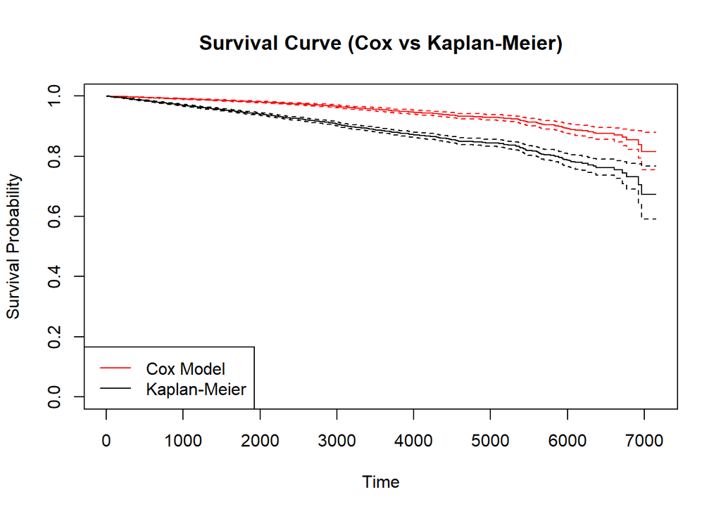

```r
surv_fit <- survfit(cox_complete)

km_fit <- survfit(surv_obj ~ 1, data = nafld)

plot(surv_fit, xlab = "Time", ylab = "Survival Probability",
     main = "Survival Curve (Cox vs Kaplan-Meier)",
     col = "red")
lines(km_fit, col = "black")
legend("bottomleft", legend = c("Cox Model", "Kaplan-Meier"), col = c("red", "black"), lty = 1)
```

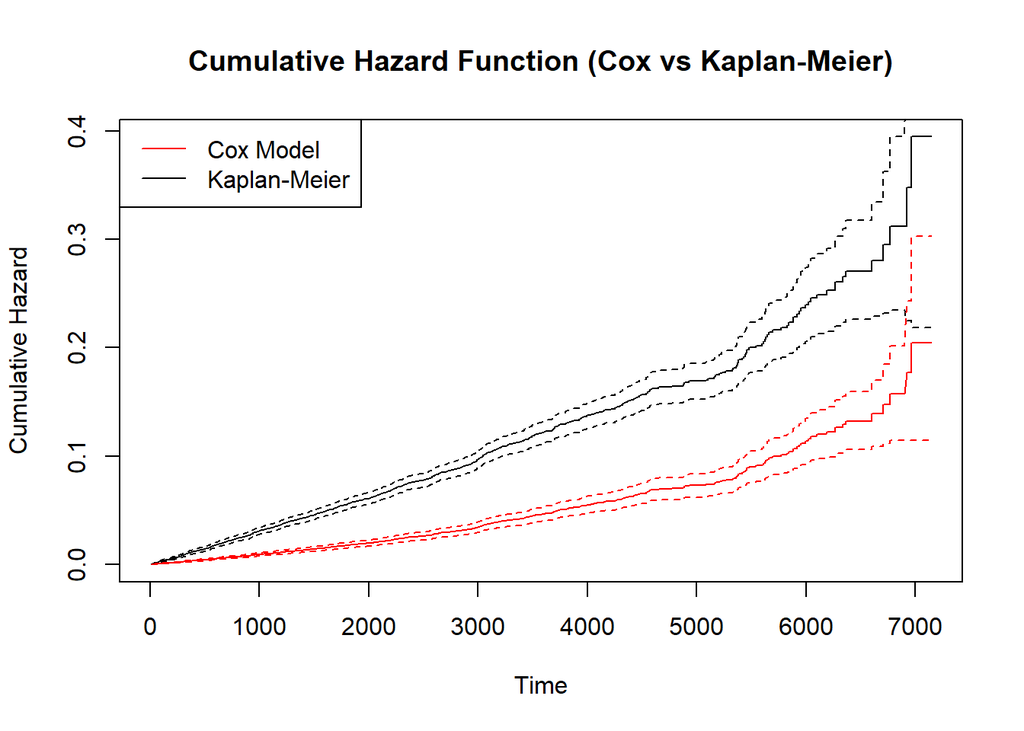

```r
km_cum_hazard <- -log(km_fit$surv)
km_cum_hazard_lower <- -log(km_fit$surv + 1.96 * km_fit$std.err)
km_cum_hazard_upper <- -log(km_fit$surv - 1.96 * km_fit$std.err)
plot(km_fit$time, km_cum_hazard, type = "s", xlab = "Time", ylab = "Cumulative Hazard",
     main = "Cumulative Hazard Function (Cox vs Kaplan-Meier)")
lines(km_fit$time, km_cum_hazard_lower, lty = 2, col = "black")
lines(km_fit$time, km_cum_hazard_upper, lty = 2, col = "black")
legend("topleft", legend = c("Cox Model", "Kaplan-Meier"), col = c("red", "black"), lty = 1)

cox_cum_hazard <- -log(surv_fit$surv)
cox_cum_hazard_lower <- -log(surv_fit$surv + 1.96 * surv_fit$std.err)
cox_cum_hazard_upper <- -log(surv_fit$surv - 1.96 * surv_fit$std.err)
lines(surv_fit$time, cox_cum_hazard, col = "red")
lines(surv_fit$time, cox_cum_hazard_lower, lty = 2, col = "red")
lines(surv_fit$time, cox_cum_hazard_upper, lty = 2, col = "red")
```

We can see that with respect to the Kaplan-Meier estimate, the cox regression overestimates the survival function and underestimates the hazards.

## TESTING THE PROPORTIONAL HAZARDS ASSUMPTION FOR OUR COX MODEL

Firstly, we plot the log-log functions for the classes of the variables. Even if we used the variables in their quantitative form, this helps up in checking if the proportional hazards assumption is respected.

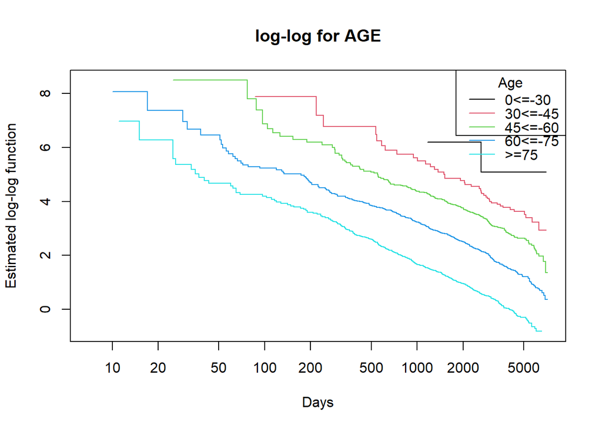

```r
attach(nafld)

surv_agecl <- survfit(surv_obj ~ agecl)
surv_bmicl <- survfit(surv_obj ~ bmicl)
surv_male <- survfit(surv_obj ~ male)


# Plot of log-minus-log function
plot(surv_agecl, fun = "cloglog", yscale = -1, col = 1:5, main = "log-log for AGE",
     xlab = "Days", ylab = "Estimated log-log function")
legend("topright", title = "Age", legend = levels(agecl), col = 1:5, lty = 1,
       x.intersp = 0.8, y.intersp = 1.2, bg = "white")
```

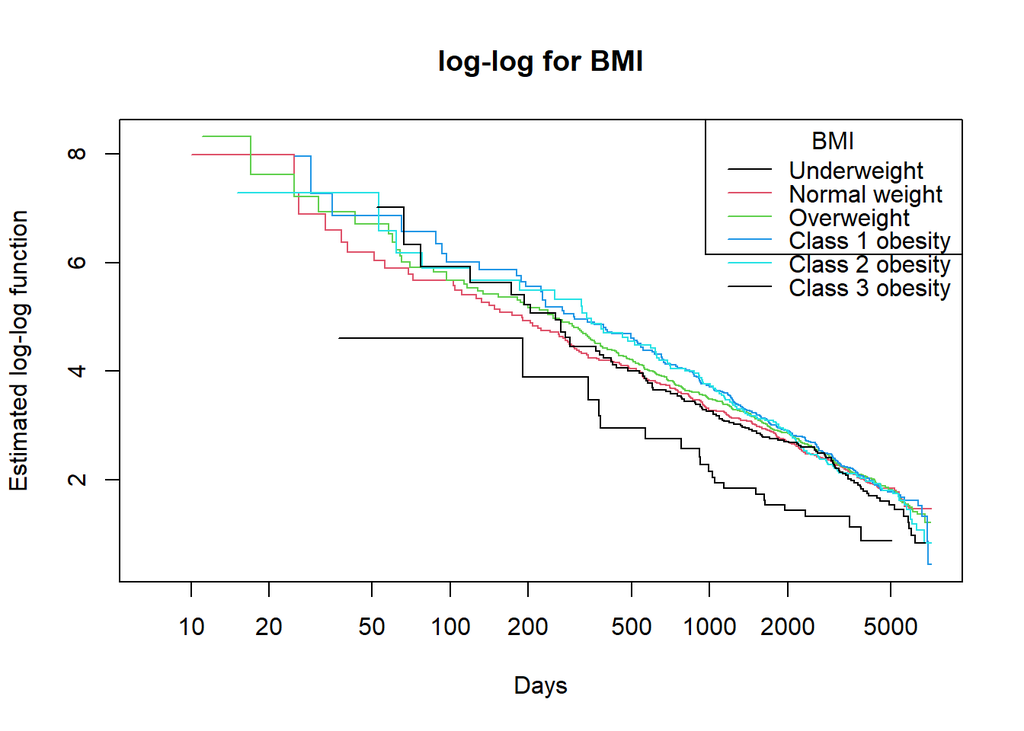

```r
plot(surv_bmicl, fun = "cloglog", yscale = -1, col = 1:5, main = "log-log for BMI",
     xlab = "Days", ylab = "Estimated log-log function")
legend("topright", title = "BMI", legend = levels(bmicl), col = 1:5, lty = 1,
       x.intersp = 0.8, y.intersp = 1.2, bg = "white")
```

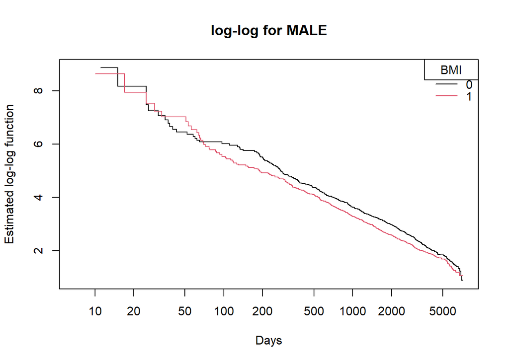

```r
plot(surv_male, fun = "cloglog", yscale = -1, col = 1:5, main = "log-log for MALE",
     xlab = "Days", ylab = "Estimated log-log function")
legend("topright", title = "BMI", legend = levels(as.factor(male)), col = 1:5, lty = 1,
       x.intersp = 0.8, y.intersp = 1.2, bg = "white")
```

```r
detach(nafld)
```

Next we compute the schoenfeld residuals and plot them with respect to the covariates. Additionally to the plots we also use the cox.zph to test the hypothesis that the hazards are proportional.

```r
ph_test_km <- cox.zph(cox_complete, terms=FALSE, transform="km")
ph_test_rank <- cox.zph(cox_complete, terms=FALSE, transform="rank")
ph_test_id <- cox.zph(cox_complete, terms=FALSE, transform="identity")
ph_test_log <- cox.zph(cox_complete, terms=FALSE, transform="log")

ph_test_km
```

```
##         chisq df     p
## age    2.2629  1 0.133
## male   0.0194  1 0.889
## bmi    3.3453  1 0.067
## GLOBAL 6.6800  3 0.083
```

```r
ph_test_rank
```

```
##         chisq df    p
## age    2.8674  1 0.09
## male   0.0219  1 0.88
## bmi    2.3342  1 0.13
## GLOBAL 6.2172  3 0.10
```

```r
ph_test_id
```

```
##        chisq df     p
## age    2.420  1 0.120
## male   0.012  1 0.913
## bmi    3.039  1 0.081
## GLOBAL 6.508  3 0.089
```

```r
ph_test_log
```

```
##        chisq df    p
## age    2.067  1 0.15
## male   0.031  1 0.86
## bmi    2.212  1 0.14
## GLOBAL 5.195  3 0.16
```

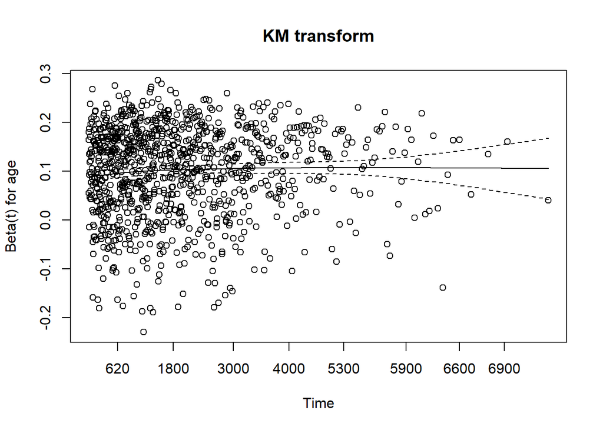

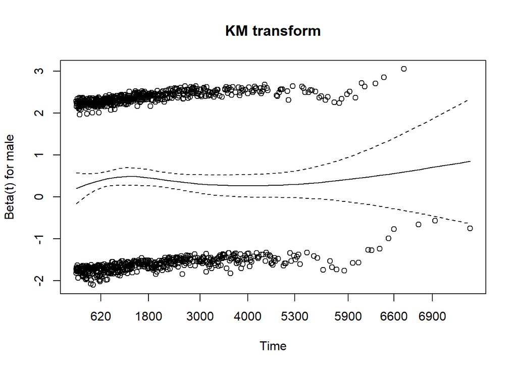

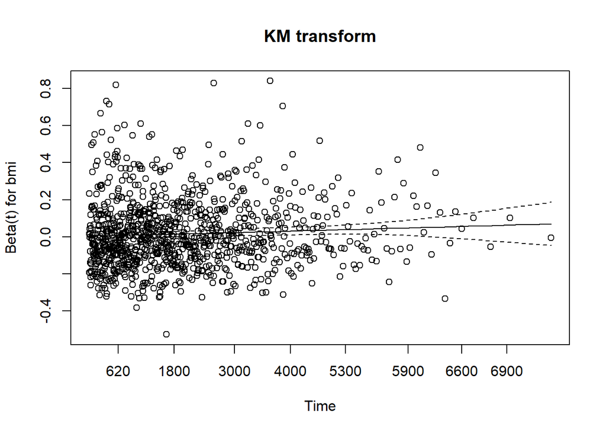

```r
plot(ph_test_km, main = "KM transform")
```

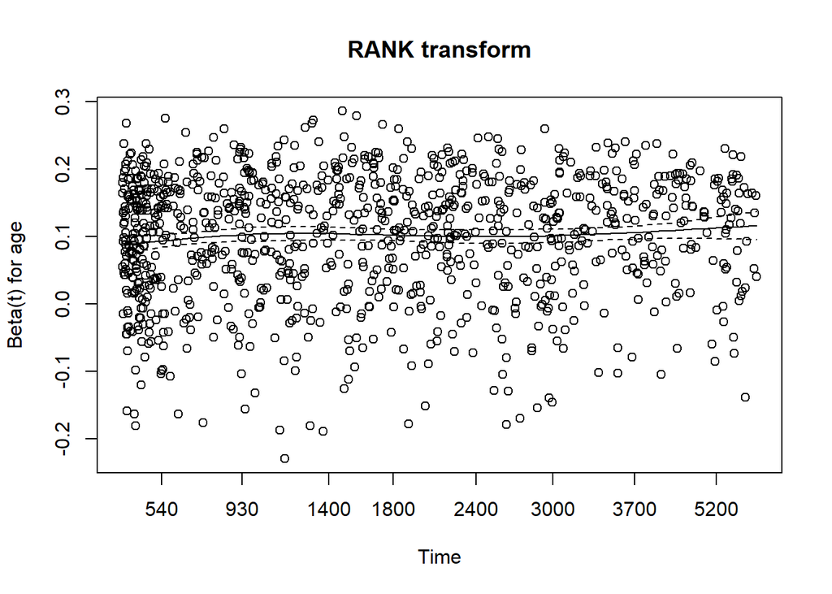

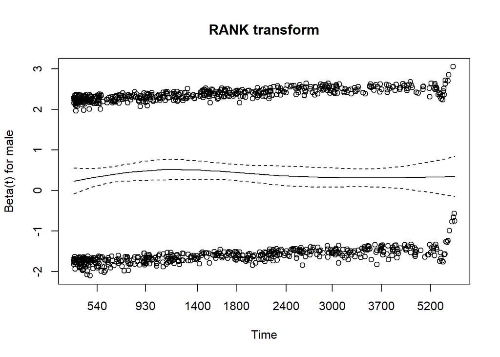

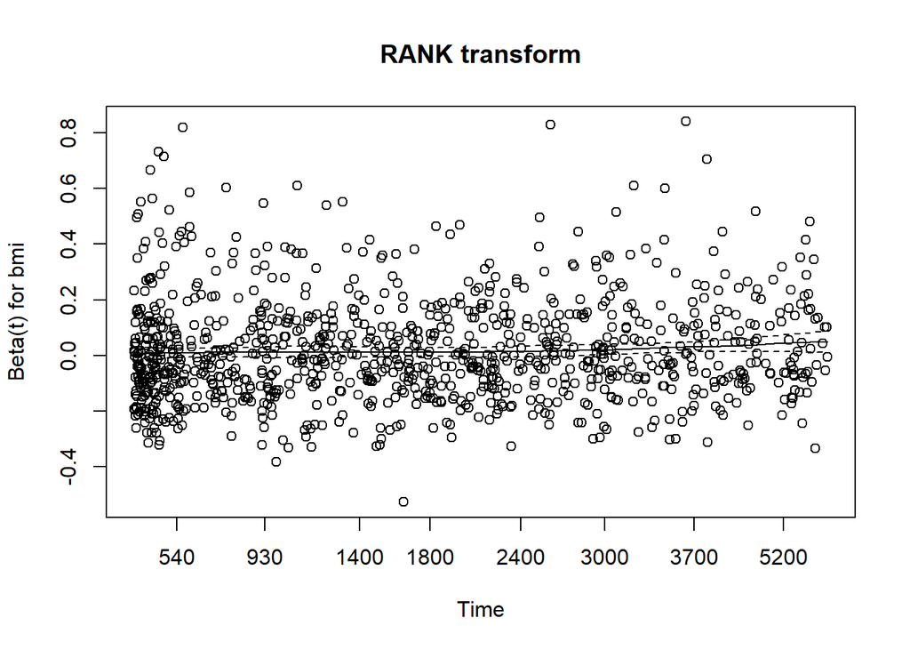

```r
plot(ph_test_rank, main = "RANK transform")
```

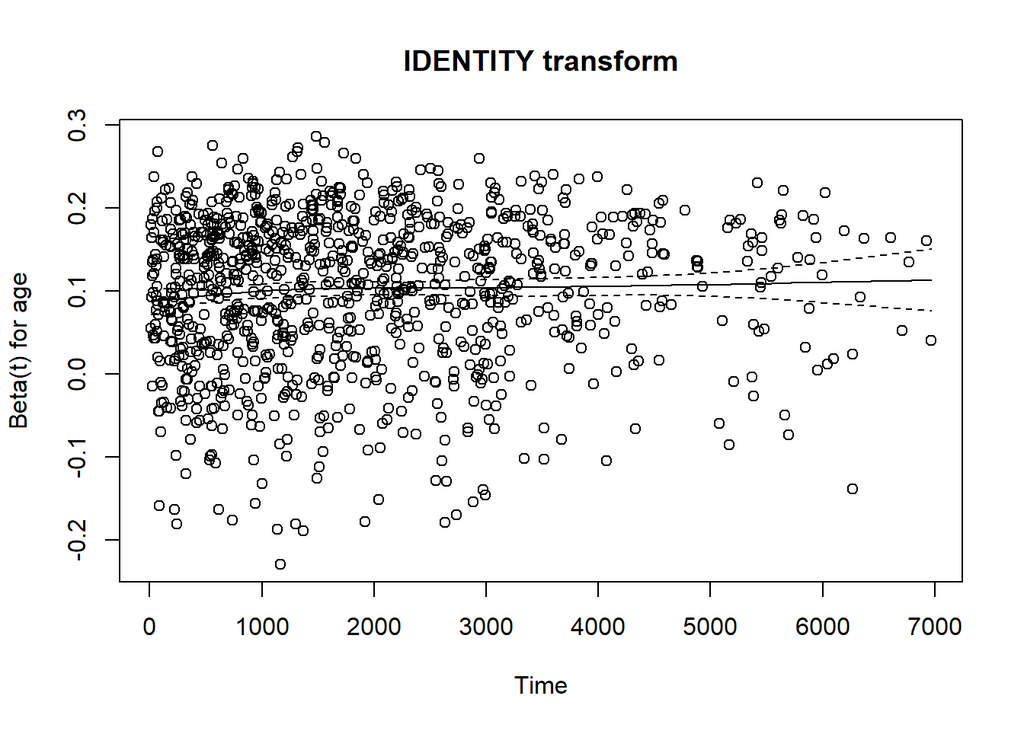

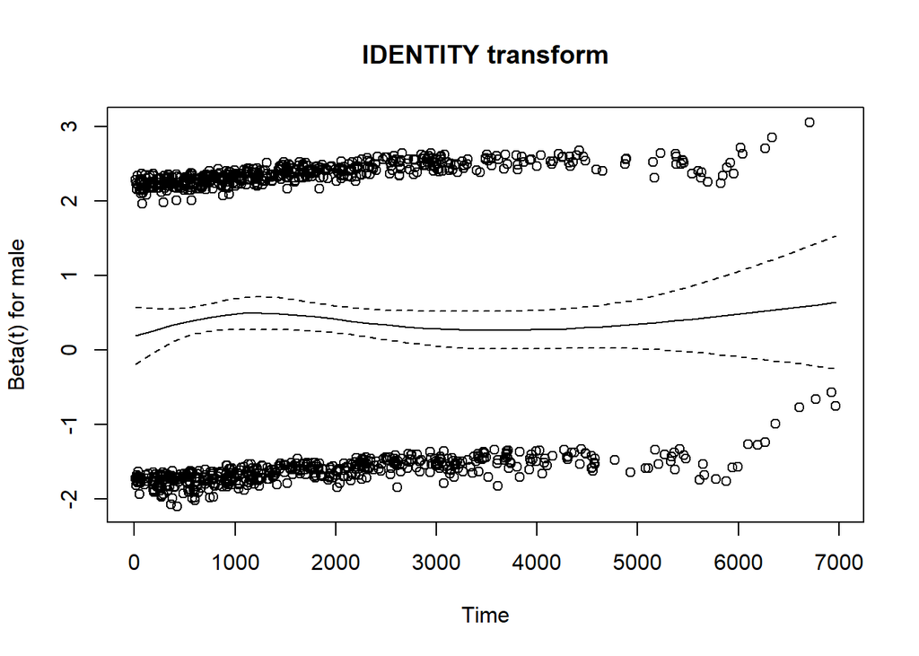

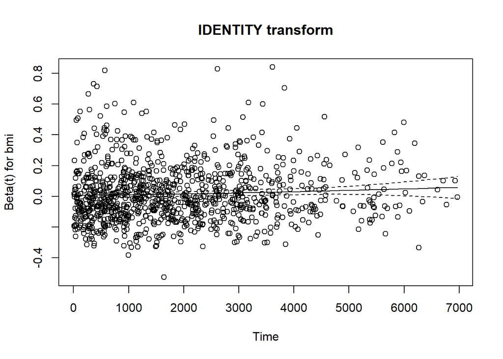

```r
plot(ph_test_id, main = "IDENTITY transform")
```

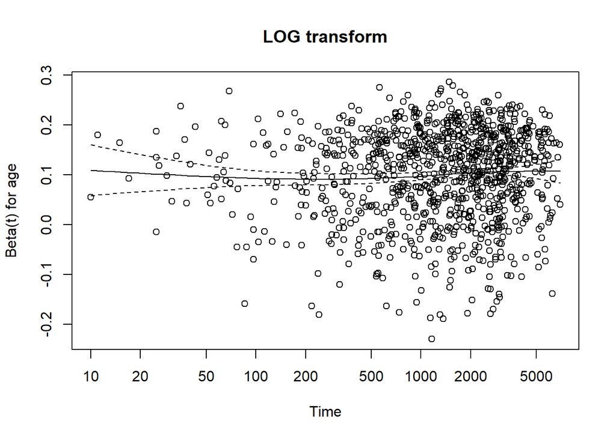

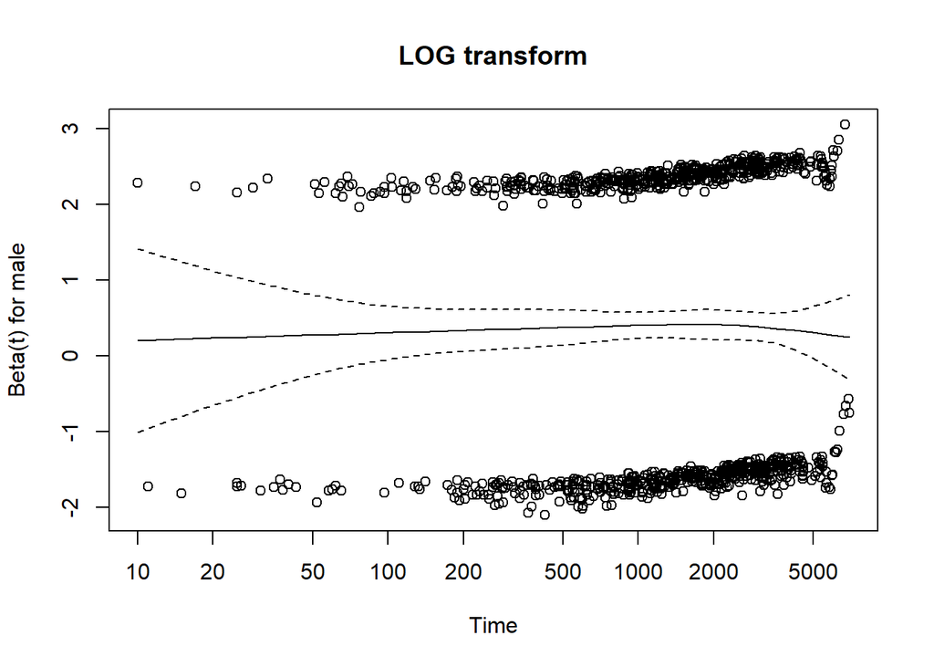

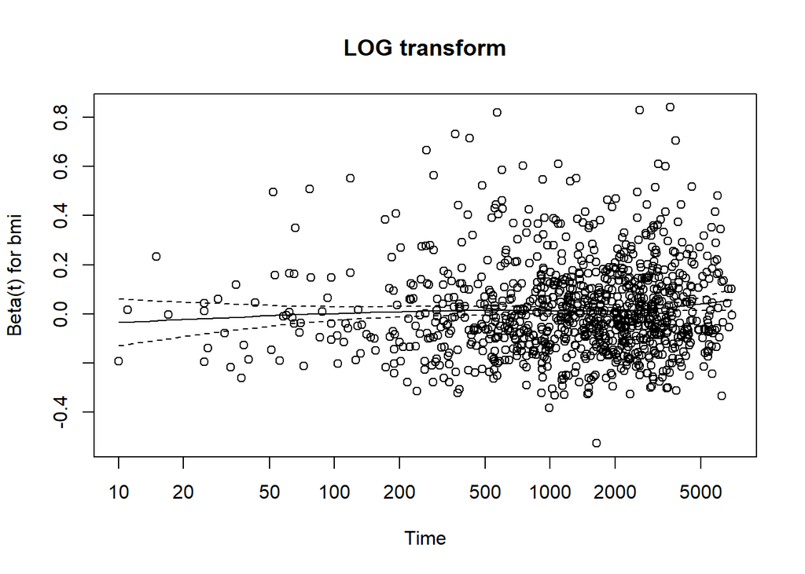

```r
plot(ph_test_log, main = "LOG transform")
```

From the plots and the non-significant p-values, we do not reject the PH assumption.

## TESTING THE LINEARITY ASSUMPTION

Finally we test the linearity assumption by plotting the martingale residuals against the covariates. “male” is excluded since it’s a binary variable

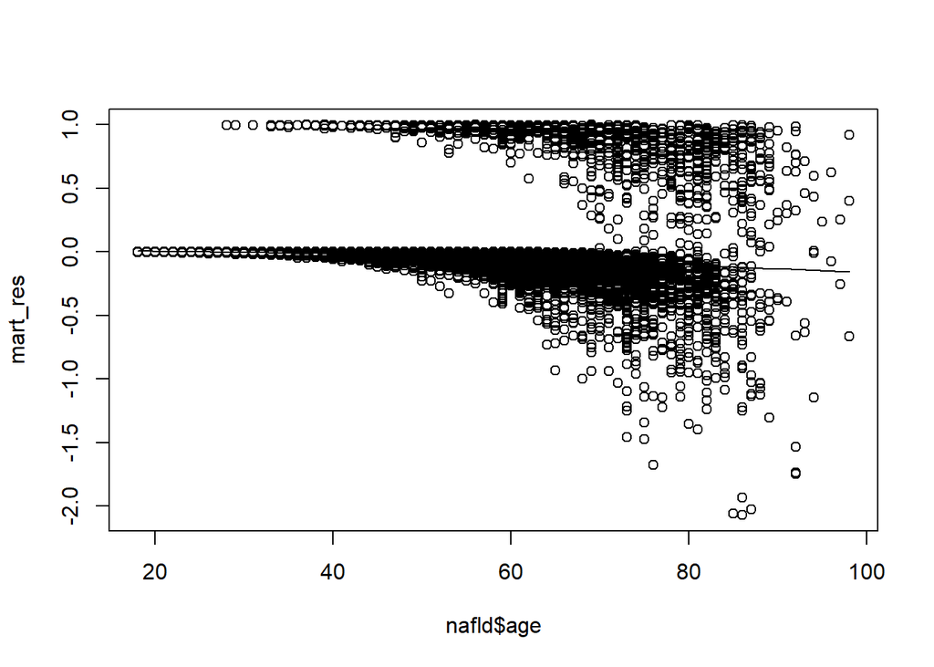

```r
attach(nafld)
mart_res <- residuals(cox_complete, type="martingale")

scatter.smooth(mart_res ~ nafld$age)
```

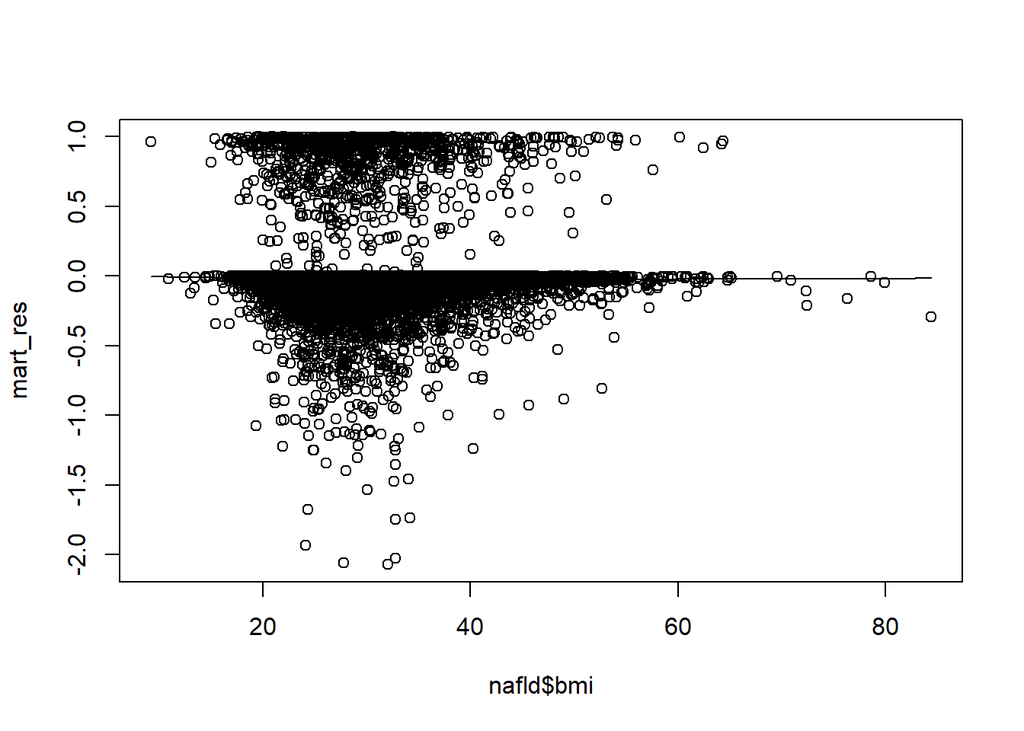

```r
scatter.smooth(mart_res ~ nafld$bmi)
```

```r
detach(nafld)
```

Graphically speaking, there is no clear evidence of non-linearity.

In order to obtain more accurate information, we now test the linearity hypothesis through the mfp function. We leave the default option select=1 so that no variable selection would be performed.

```r
cox_mfp <- mfp(surv_obj ~ fp(age)+male+fp(bmi), family=cox, method="breslow", verbose=T,data=nafld)
```

```
##
##  Variable    Deviance    Power(s)
## ------------------------------------------------
## Cycle 1
##  age
##              17601.31
##              15874.51    1
##              15858.96    2
##              15857.19    -2 2
##
##  male
##              15892.58
##              15858.96    1
##
##
##
##  bmi
##              15873.4
##              15858.96    1
##              15847.83    3
##              15798.44    -0.5 0
##
## Cycle 2
##  age
##              17572.5
##              15812.58    1
##              15798.44    2
##              15796.19    -2 2
##
##  male
##              15841.89
##              15798.44    1
##
##
##
##
## Tansformation
##      shift scale
## age      0   100
## male     0     1
## bmi      0    10
##
## Fractional polynomials
##      df.initial select alpha df.final power1 power2
## age           4      1  0.05        2      2      .
## male          1      1  0.05        1      1      .
## bmi           4      1  0.05        4   -0.5      0
##
##
## Transformations of covariates:
##                             formula
## age                  I((age/100)^2)
## male                           male
## bmi  I((bmi/10)^-0.5)+log((bmi/10))
##
##
## Deviance table:
##           Resid. Dev
## Null model    17618.83
## Linear model  15874.51
## Final model   15798.44
```

```r
cox_mfp
```

```
## Call:
## mfp(formula = surv_obj ~ fp(age) + male + fp(bmi), data = nafld,
##     family = cox, method = "breslow", verbose = T)
##
##
## Deviance table:
##           Resid. Dev
## Null model    17618.83
## Linear model  15874.51
## Final model   15798.44
##
## Fractional polynomials:
##      df.initial select alpha df.final power1 power2
## age           4      1  0.05        2      2      .
## male          1      1  0.05        1      1      .
## bmi           4      1  0.05        4   -0.5      0
##
##
## Transformations of covariates:
##                             formula
## age                  I((age/100)^2)
## male                           male
## bmi  I((bmi/10)^-0.5)+log((bmi/10))
##
##           coef exp(coef) se(coef)      z       p
## age.1   7.6206 2.040e+03   0.1814 42.000 0.0e+00
## male.1  0.4181 1.519e+00   0.0632  6.616 3.7e-11
## bmi.1  38.2754 4.196e+16   3.4217 11.186 0.0e+00
## bmi.2  11.4716 9.595e+04   1.0141 11.313 0.0e+00
##
## Likelihood ratio test=1820  on 4 df, p=0 n= 12562
```

```r
cox_mfp$pvalues
```

```
##            p.null        p.lin         p.FP power2 power4.1 power4.2
## age  0.000000e+00 9.439763e-04 3.245891e-01      2     -2.0        2
## male 4.350946e-11           NA           NA     NA       NA       NA
## bmi  2.039386e-15 4.552493e-13 1.888699e-11      3     -0.5        0
```

From the output, we observe that:

1. In the final model, age and bmi have 2 and 4 degrees of freedom respectively, meaning that a linear form of such covariates is less preferable than another form with which the model fitting is better.
2. In the case of age, df=2 means that age is transformed into a power of (scled) age; specifically age is transformed into (age/100)^2 (scale=100 and power=2). We also remark that the reduction in the deviance residuals from df=2 to df=4 is negligible.
3. In the case of bmi, df=4 means that bmi is transformed into the sum of two functions of the (scaled) bmi. Since we have power1=-0.5, power2=0 refers to the logarithm and scale=10, bmi is transformed into (bmi/10)^(-1/2) + ln(bmi/10).

# PARAMETRIC MODELS

We also try to fit a series of parametric models with and without covariates.

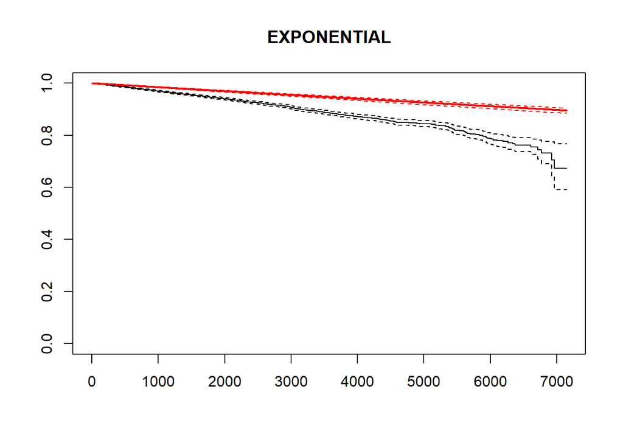

```r
attach(nafld)
mod_expPH <- flexsurvreg(surv_obj ~ age+male+bmi, dist="exp")
mod_wei <- flexsurvreg(surv_obj ~ age+male+bmi, dist="weibull")
mod_lnr <- flexsurvreg(surv_obj ~ age+male+bmi, dist="lnorm")
mod_llg <- flexsurvreg(surv_obj ~ age+male+bmi, dist="llogis")

AIC_vec = AIC(mod_expPH,mod_wei,mod_lnr,mod_llg)
BIC_vec = BIC(mod_expPH,mod_wei,mod_lnr,mod_llg)

plot(mod_expPH, main = "EXPONENTIAL")
```

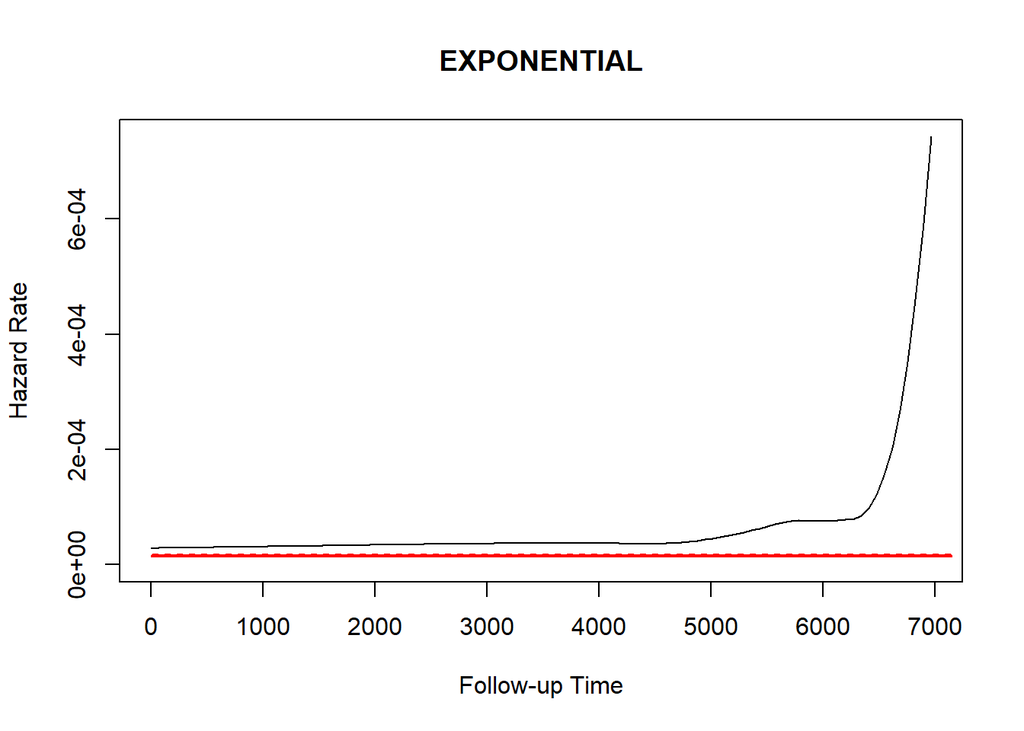

```r
plot(mod_expPH,type="hazard", main = "EXPONENTIAL")
```

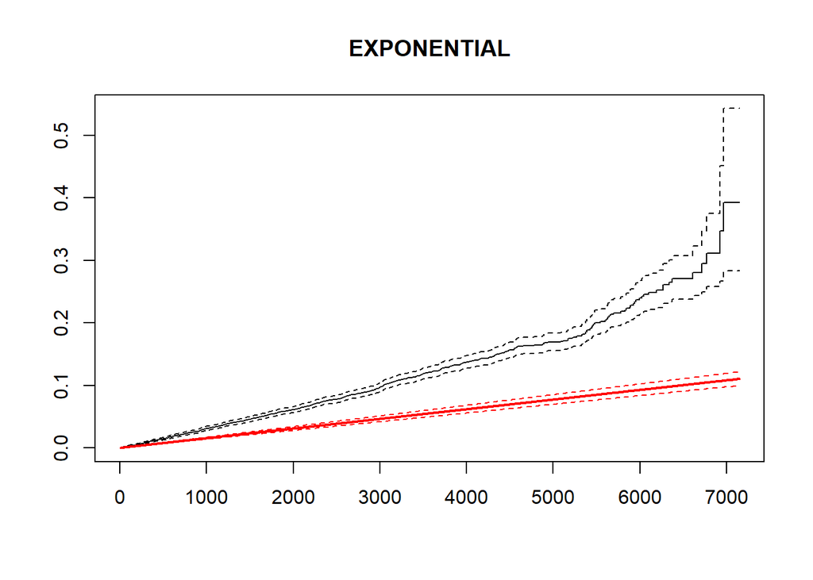

```r
plot(mod_expPH,type="cumhaz", main = "EXPONENTIAL")
```

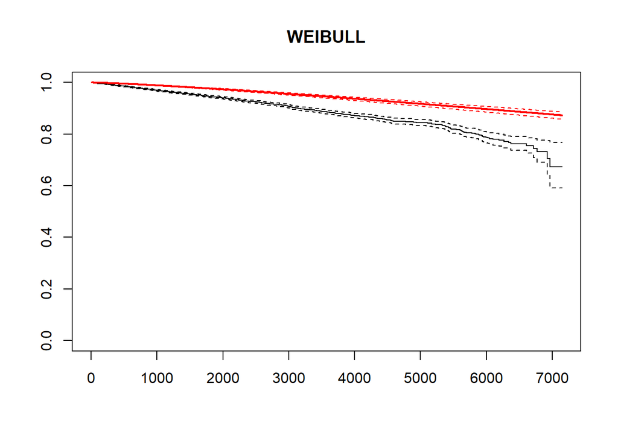

```r
plot(mod_wei, main = "WEIBULL")
```